## Weather Impact on Uber Ridership

Taikan Nakada

3/8/2019

### Introduction

Uber is a revolutionary change for New York City ridership culture. The convenience is unparalleled and is sharply challenging the yellow taxi services in the five boroughs. As a resident of New York and a heavy user of Uber, I would like to examine the number of trips per borough in NYC, and see how the weather impacts the changes in number of trips.

### The Data Set

Data is sourced from [NYC Uber Pickups with Weather and Holidays](https://www.kaggle.com/yannisp/uber-pickups-enriched), created by Yannis Pappas. This is a forked subset of the [Uber Pickups in New York City](https://inclass.kaggle.com/fivethirtyeight/uber-pickups-in-new-york-city), enriched with weather data from [National Centers for Environmental Information](https://www.ncdc.noaa.gov/), borough and holidays information.

```r
raw_data <- read.csv('/Users/taikannakada/R/Econ320/FinalProject/uber_nyc_enriched.csv')
# import .csv file into R as data
df <- raw_data
```

### Variables

We will be examining the following variables:

- pickup_dt: Time period of the observations.
- borough: NYC’s borough.
- pickups: Number of pickups for the period.
- spd: wind speed (mph)
- temp: temperature in Fahrenheit.
- dewp: dew point in f¥Fahrenheint
- slp: sea level pressure
- pcp01: 1-hour liquid precipitation.
- pcp06: 6-hour liquid precipitation.
- pcp24: 24-hour liquid precipitation.
- sd: Snow depth in inches.
- hday: being a holiday (Y) or (N)

### Summary of Data

```r
stargazer(df, type="text")
```

```
##
## =========================================================================
## Statistic   N      Mean    St. Dev.   Min   Pctl(25)  Pctl(75)     Max
## -------------------------------------------------------------------------
## pickups   29,101  490.216  995.650     0        1        449      7,883
## spd       29,101   5.985    3.699      0        3         8        21
## vsb       29,101   8.818    2.443      0       9.1       10        10
## temp      29,101  47.669    19.815     2       32       64.5       89
## dewp      29,101  30.823    21.283    -16      14        50        73
## slp       29,101 1,017.818  7.769   991.400 1,012.500 1,022.900 1,043.400
## pcp01     29,101   0.004    0.019      0        0         0         0
## pcp06     29,101   0.026    0.093      0        0         0         1
## pcp24     29,101   0.090    0.219      0        0       0.05        2
## sd        29,101   2.529    4.520      0        0        3.0       19
## -------------------------------------------------------------------------
```

### Borough Importance

My initial intution was to examine the data based on the boroughs. Let’s first see if there is any difference in the correlation plots between the different boroughs, and compare that with the plot for the aggregated correlation plot. Doing so will allow us to see if theres any significant differences between the boroughs. However, since my main motive is to see the pattern in NYC as a whole, I eventually will be aggregating the data of all the boroughs and eliminating the “borough” variable. Eliminating the borough variable requires me to take the average of all the weather components.

```r
# Creating a dataframe for the Bronx
df_bronx <- df %>%
  filter(borough == 'Bronx') %>% # filter Bronx from initial data
  select(-borough) %>%
  mutate(id = 1:length(unique(df$pickup_dt)), # use lubridate package to extract important date information in an organized matter
         month = month(pickup_dt),
         day = day(pickup_dt),
         wday = wday(pickup_dt),
         hour = hour(pickup_dt),
         hday = (hday=="Y"),
         wday_hday = ifelse(hday==TRUE, 8, wday)) %>%
  select(-pickup_dt) %>%
  select(id, everything())

# Creating a dataframe for the Brooklyn
df_brooklyn <- df %>%
  filter(borough == 'Brooklyn') %>% # filter Brooklyn from data
  select(-borough) %>%
  mutate(id = 1:length(unique(df$pickup_dt)), # use lubridate package to extract important date information in an organized matter
         month = month(pickup_dt),
         day = day(pickup_dt),
         wday = wday(pickup_dt),
         hour = hour(pickup_dt),
         hday = (hday=="Y"),
         wday_hday = ifelse(hday==TRUE, 8, wday)) %>%
  select(-pickup_dt) %>%
  select(id, everything())

# Creating dataframe for Manhattan
df_manhattan <- df %>%
  filter(borough == 'Manhattan') %>% # filter Manhattan from data
  select(-borough) %>%
  mutate(id = 1:length(unique(df$pickup_dt)), # use lubridate package to extract important date information in an organized matter
         month = month(pickup_dt),
         day = day(pickup_dt),
         wday = wday(pickup_dt),
         hour = hour(pickup_dt),
         hday = (hday=="Y"),
         wday_hday = ifelse(hday==TRUE, 8, wday)) %>%
  select(-pickup_dt) %>%
  select(id, everything())

# Creating dataframe for Queens
df_queens <- df %>%
  filter(borough == 'Queens') %>% # filter Queens from data
  select(-borough) %>%
  mutate(id = 1:length(unique(df$pickup_dt)), # use lubridate package to extract important date information in an organized matter
         month = month(pickup_dt),
         day = day(pickup_dt),
         wday = wday(pickup_dt),
         hour = hour(pickup_dt),
         hday = (hday=="Y"),
         wday_hday = ifelse(hday==TRUE, 8, wday)) %>%
  select(-pickup_dt) %>%
  select(id, everything())
```

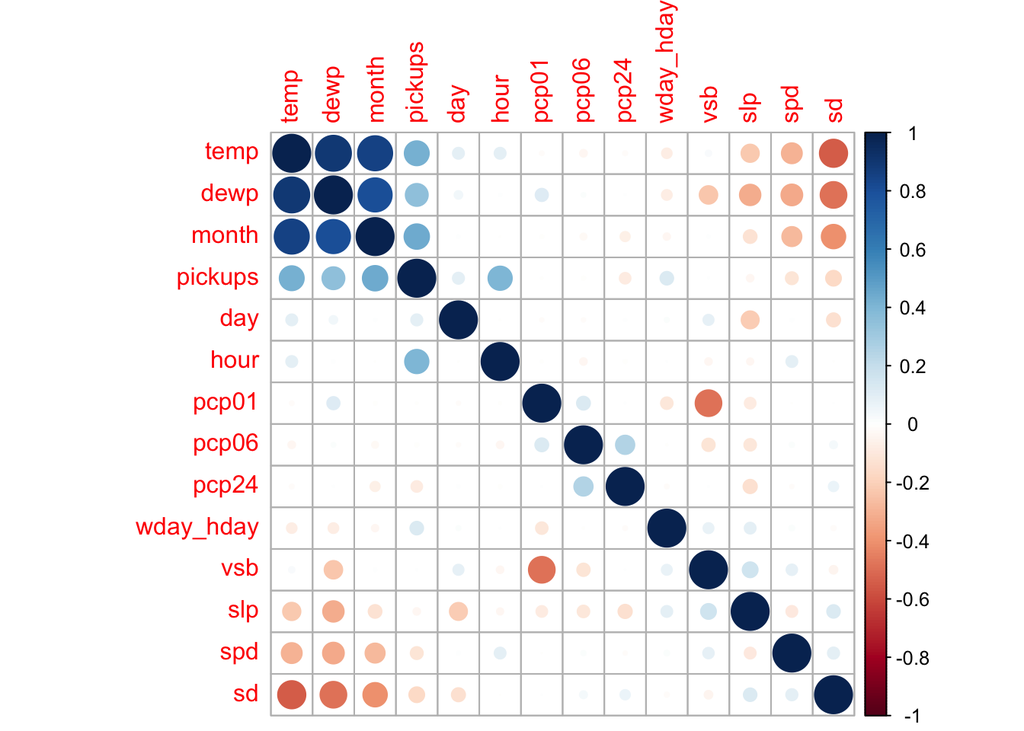

```r
# Correlation plot of variables for just the Bronx
correlations_bronx <- cor(df_bronx[,c('month', 'day', 'wday_hday', 'hour', 'pickups', 'spd', 'vsb', 'temp', 'dewp', 'slp', 'pcp01', 'pcp06', 'pcp24', 'sd')])
corrplot(correlations_bronx, order = 'FPC')
```

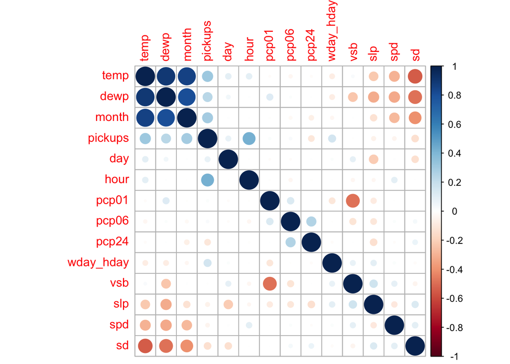

```r
# Correlation plot of variables for just Brooklyn
correlations_brooklyn <- cor(df_brooklyn[,c('month', 'day', 'wday_hday', 'hour', 'pickups', 'spd', 'vsb', 'temp', 'dewp', 'slp', 'pcp01', 'pcp06', 'pcp24', 'sd')])
corrplot(correlations_brooklyn, order = 'FPC')
```

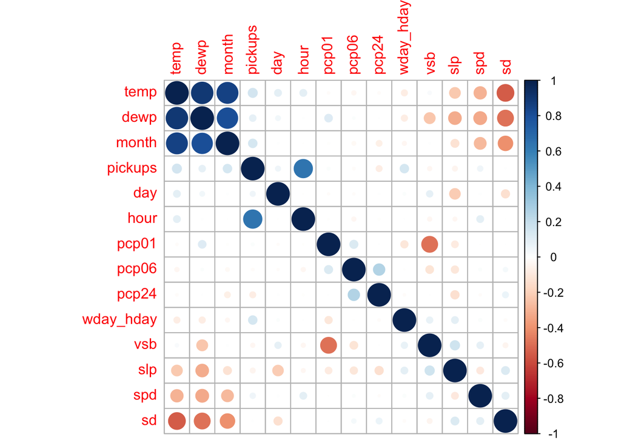

```r
# Correlation plot of variables for just Manhattan
correlations_manhattan <- cor(df_manhattan[,c('month', 'day', 'wday_hday', 'hour', 'pickups', 'spd', 'vsb', 'temp', 'dewp', 'slp', 'pcp01', 'pcp06', 'pcp24', 'sd')])
corrplot(correlations_manhattan, order = 'FPC')
```

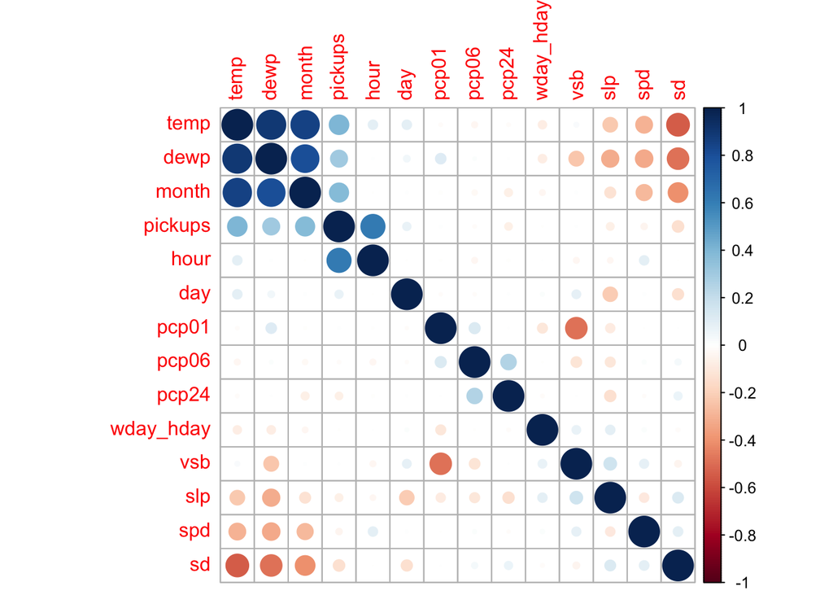

```r
# Correlation plot of variables for just Queens
correlations_queens <- cor(df_queens[,c('month', 'day', 'wday_hday', 'hour', 'pickups', 'spd', 'vsb', 'temp', 'dewp', 'slp', 'pcp01', 'pcp06', 'pcp24', 'sd')])
corrplot(correlations_queens, order = 'FPC')
```

It’s obvious that all the boroughs follow a very similar pattern. Therefore, I will go on to aggregate the boroughs and use that data for the rest of the dat. But it is also interesting to see how much of the variance is caused by the different boroughs. Simply stated, which borough is most influencing the patterns of our data?

### Box M Test

Principal component is an import tool used in exploratory data analysis. It can be done by eigenvalue decomposition of a correlation matrix. We will use the Box M-Test for this.

Without going in to detail, the eigenvalues or a correlation matrix correspond to the variances along the principal component axis of the data points. The largest eigenvalue corresponds to the maximal variance with respect to the data.

Need to set borough as a factor. It seems there are some NA values for borough so also need to get rid of these records.

```r
df_borough <- raw_data %>%
    filter(!is.na(borough)) %>%
    mutate(id = 1:n(),
         borough = as.factor(borough),
         month = month(pickup_dt),
         day = day(pickup_dt),
         wday = wday(pickup_dt),
         hour = hour(pickup_dt),
         hday = (hday=="Y"),
         wday_hday = ifelse(hday==TRUE, 8, wday)) %>%
    select(-pickup_dt) %>%
    select(id, everything())
```

```r
#str(df)
results <- boxM(df_borough[,c(3:18)], df_borough$borough)

results
```

```
##
##  Box's M-test for Homogeneity of Covariance Matrices
##
## data:  df_borough[, c(3:18)]
## Chi-Sq (approx.) = 166100, df = 680, p-value < 2.2e-16
```

```r
summary(results)
```

```
## Summary for Box's M-test of Equality of Covariance Matrices
##
## Chi-Sq:   166099.5
## df:   680
## p-value: < 2.2e-16
##
## log of Covariance determinants:
##         Bronx      Brooklyn           EWR     Manhattan        Queens
##     14.362395     18.991517      4.337797     21.861109     17.303407
## Staten Island        pooled
##      8.810896     20.662945
##
## Eigenvalues:
##           Bronx     Brooklyn          EWR    Manhattan       Queens
## 1  1.253549e+03 8.698720e+04 8.140227e+02 2.058469e+06 2.395665e+04
## 2  5.348124e+02 7.504577e+02 8.282385e+01 8.019862e+02 7.095409e+02
## 3  8.274585e+01 8.267601e+01 6.125934e+01 8.267622e+01 8.276209e+01
## 4  5.742139e+01 5.848097e+01 4.997865e+01 5.906080e+01 5.784941e+01
## 5  4.443166e+01 4.363649e+01 3.259280e+01 3.724726e+01 3.669142e+01
## 6  3.096986e+01 3.164498e+01 1.439289e+01 2.626511e+01 2.695710e+01
## 7  1.432756e+01 1.439108e+01 1.092750e+01 1.433552e+01 1.426274e+01
## 8  1.092569e+01 1.092748e+01 7.844432e+00 1.090267e+01 1.090996e+01
## 9  7.513155e+00 7.494595e+00 3.627703e+00 7.343864e+00 7.836930e+00
## 10 3.627498e+00 3.621285e+00 7.102575e-01 3.607527e+00 3.627693e+00
## 11 6.686504e-01 6.961952e-01 5.251465e-01 6.932562e-01 6.744064e-01
## 12 5.247879e-01 5.249830e-01 4.563706e-02 5.228950e-01 5.179469e-01
## 13 4.549883e-02 4.533885e-02 2.575719e-02 4.552074e-02 4.550211e-02
## 14 7.763730e-03 7.717194e-03 7.778791e-03 7.773890e-03 7.767637e-03
## 15 2.814942e-03 2.813575e-03 2.815094e-03 2.815002e-03 2.812759e-03
## 16 2.648137e-04 2.644186e-04 2.647472e-04 2.645936e-04 2.645698e-04
##    Staten Island       pooled
## 1   8.141656e+02 3.617026e+05
## 2   8.282628e+01 8.073460e+02
## 3   6.133706e+01 8.277019e+01
## 4   5.008140e+01 6.008638e+01
## 5   3.262498e+01 4.637499e+01
## 6   1.439308e+01 3.210282e+01
## 7   1.092783e+01 1.438611e+01
## 8   7.911089e+00 1.092475e+01
## 9   3.631706e+00 7.776236e+00
## 10  2.277561e+00 3.625434e+00
## 11  6.946491e-01 7.070710e-01
## 12  5.250674e-01 5.250174e-01
## 13  4.554491e-02 4.561215e-02
## 14  7.787113e-03 7.783574e-03
## 15  2.813883e-03 2.815143e-03
## 16  2.649022e-04 2.648703e-04
##
## Statistics based on eigenvalues:
##                  Bronx     Brooklyn          EWR    Manhattan       Queens
## product   1.727862e+06 1.769747e+08 7.653876e+01 3.120032e+09 3.271705e+07
## sum       2.041574e+03 8.799181e+04 1.078788e+03 2.059514e+06 2.490833e+04
## precision 2.333000e-04 2.329408e-04 2.311784e-04 2.331410e-04 2.330984e-04
## max       1.253549e+03 8.698720e+04 8.140227e+02 2.058469e+06 2.395665e+04
##           Staten Island       pooled
## product    6.706928e+03 9.414625e+08
## sum        1.081453e+03 3.627693e+05
## precision  2.333636e-04 2.333711e-04
## max        8.141656e+02 3.617026e+05
```

Roughly, our interpretation is that the data that we are using, and the patterns that we are seeing are largely driven, in order, by Manhattan, Brooklyn, Queens, Bronx, Staten Island, and finally EWR.

### Finalizing Data for Analysis

Now prepare the data for the rest of the analysis in this project.

```r
df <- df %>%
  select(-borough) %>% # eliminate the borough variable
  group_by(pickup_dt, hday) %>%
  summarise(pickups = sum(pickups), # take the average of the information that was originally separete by borughs
            spd = mean(spd),
            vsb = mean(vsb),
            temp = mean(temp),
            dewp = mean(dewp),
            slp = mean(slp),
            pcp01 = mean(pcp01),
            pcp06 = mean(pcp06),
            pcp24 = mean(pcp24),
            sd = mean(sd)) %>%
  ungroup()
```

```r
# using the lubridate package, we will change the pickup_dt variable into separate variable to describe the occurance

df<- df %>%
  mutate(id = 1:length(unique(df$pickup_dt)),
         month = month(pickup_dt), # make variable month
         day = day(pickup_dt), # make variable for day
         wday = wday(pickup_dt), # make variable for day of week
         hour = hour(pickup_dt), # make variable for the hour
         hday = (hday=="Y"),
         wday_hday = ifelse(hday==TRUE, 8, wday)) %>% # make a separate date for a weekday holiday
  select(-pickup_dt) %>%
  select(id, everything())
```

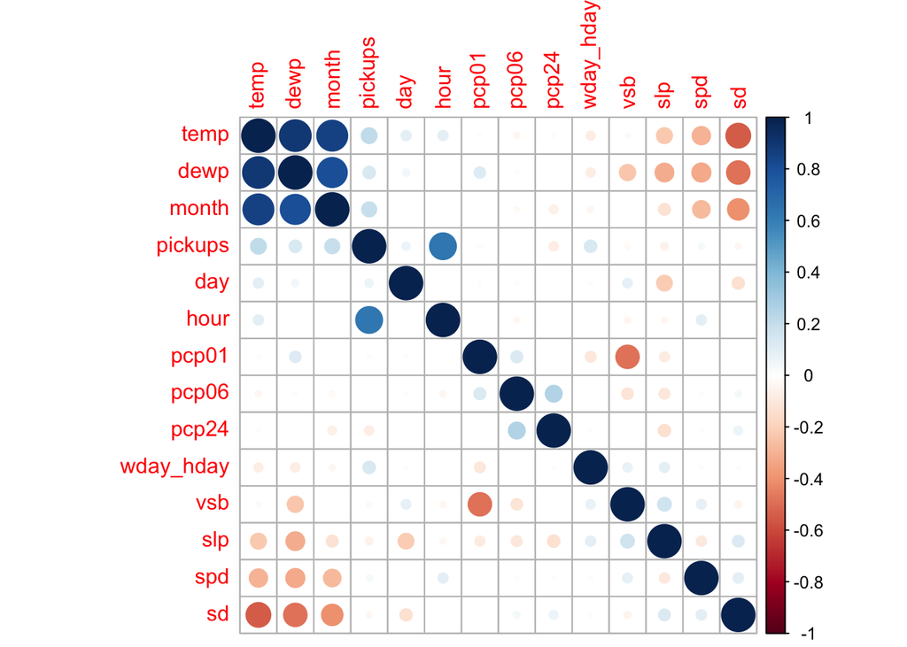

```r
correlations <- cor(df[,c('month', 'day', 'wday_hday', 'hour', 'pickups', 'spd', 'vsb', 'temp', 'dewp', 'slp', 'pcp01', 'pcp06', 'pcp24', 'sd')])
non_weather_correlations <- cor(df[,c('month', 'day', 'wday_hday', 'hour', 'pickups')])
weather_correlations <- cor(df[,c('spd', 'vsb', 'temp', 'dewp', 'slp', 'pcp01', 'pcp06', 'pcp24', 'sd')])

corrplot(correlations, order = 'FPC')
```

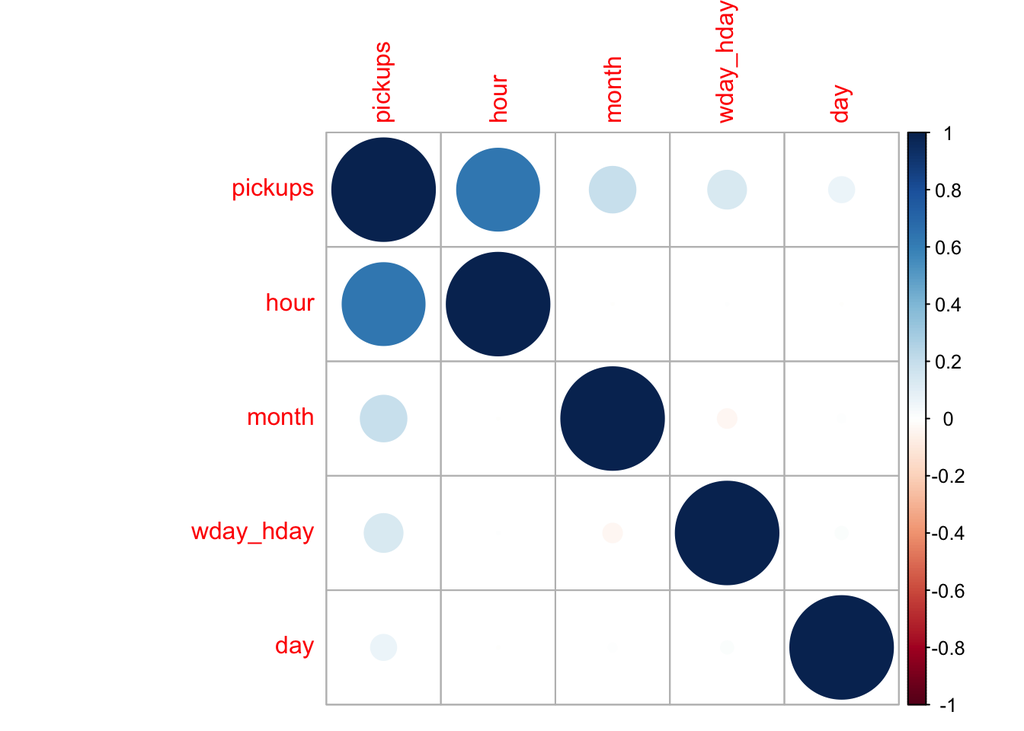

```r
corrplot(non_weather_correlations, order = 'FPC')
```

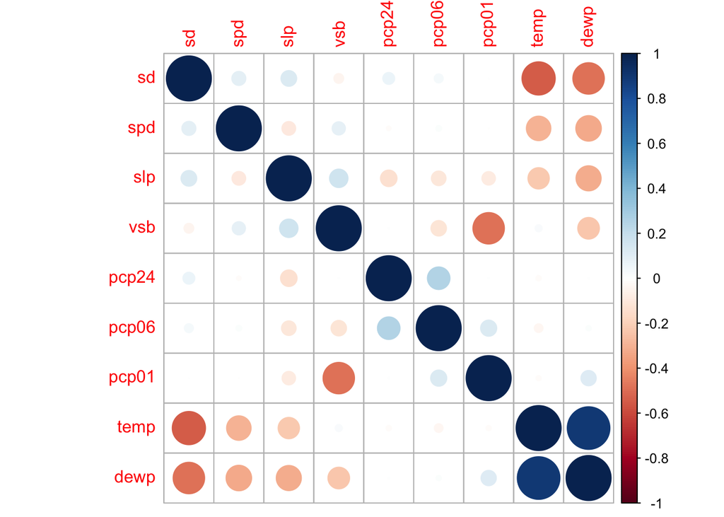

```r
corrplot(weather_correlations, order = 'FPC')
```

The correlation plots with all the variables conglomerated, and then two separate ones with just weather and another for just date variables. From an initial glance, we can see that the dates have a significantly larger impact than the weather variables.

It is no surprise that the hour of the day has a very high correlation to the number of pickups. We see that the month and day of the week/holiday do as well to a lesser extent.

Let’s take a look at the distribution of pickups over the values of these date variables.

### Motivation

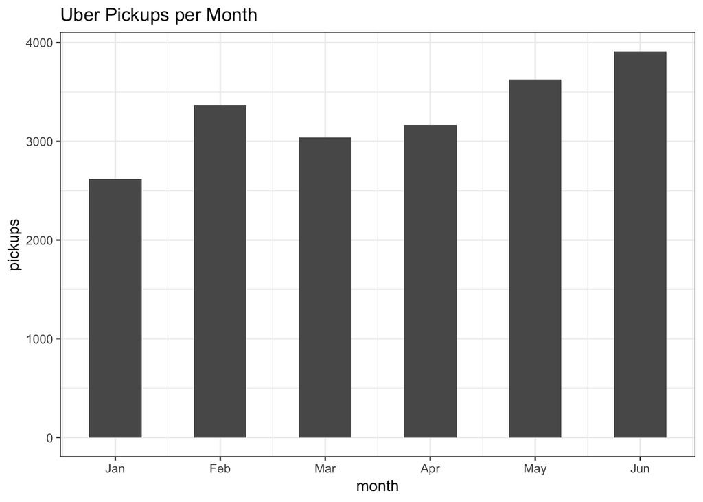

```r
df %>%
    select(month, pickups) %>%
    group_by(month) %>%
    summarise(pickups = mean(pickups)) %>%
    ggplot(aes(month, pickups)) +
    geom_col(width = 0.5) +
    labs(title = "Uber Pickups per Month")+
    scale_x_continuous(breaks = 1:6, labels = c("Jan", "Feb", "Mar", "Apr", "May","Jun"))+
    theme_bw()
```

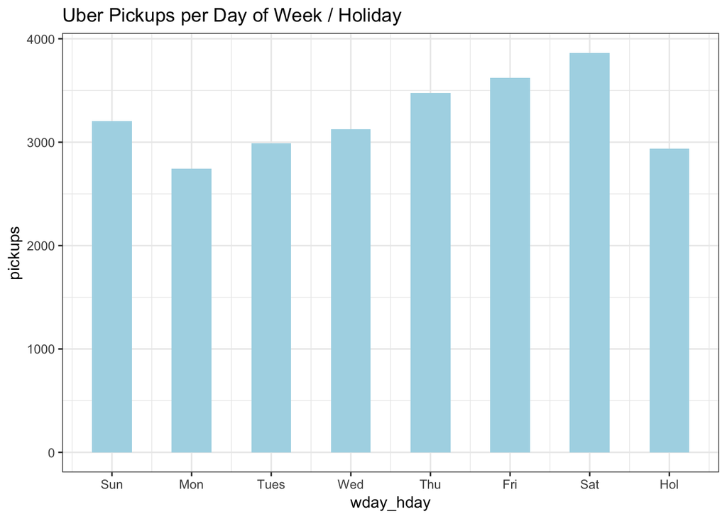

```r
df %>%
    select(wday_hday, pickups) %>%
    group_by(wday_hday) %>%
    summarise(pickups = mean(pickups)) %>%
    ggplot(aes(wday_hday, pickups)) +
    geom_col(fill="lightblue", width = 0.5) +
    labs(title = "Uber Pickups per Day of Week / Holiday") +
    scale_x_continuous(breaks = 1:8, labels = c("Sun", "Mon", "Tues", "Wed", "Thu","Fri", "Sat", "Hol"))+
    theme_bw()
```

With the exception of February, there is a month on month upward trend in pickups. It’s likely explained by the fact that the number of Uber drivers is roughly increasing, as it is an alternative to make money

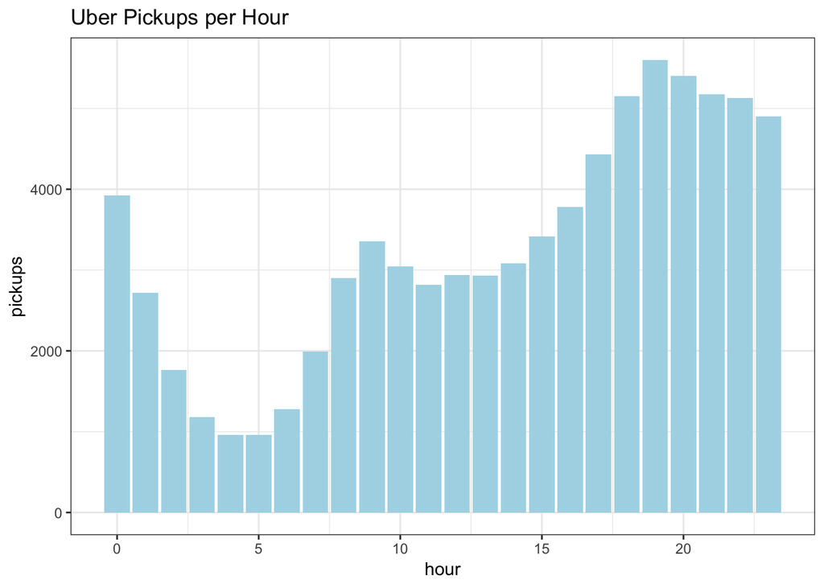

```r
df %>%
    select(hour, pickups) %>%
    group_by(hour) %>%
    summarise(pickups = mean(pickups)) %>%
    ggplot(aes(hour, pickups)) +
    geom_col(fill="lightblue") +
    labs(title = "Uber Pickups per Hour")+
    theme_bw()
```

### Regression Analysis

I will use the Variable Importance results of a Random Forest to determine the degree to which weather related variables explain variance in Uber pickups. I will first create a random forest for just the date variables, one just just weather, and then another for all the variables together and see how the variables account for variance.

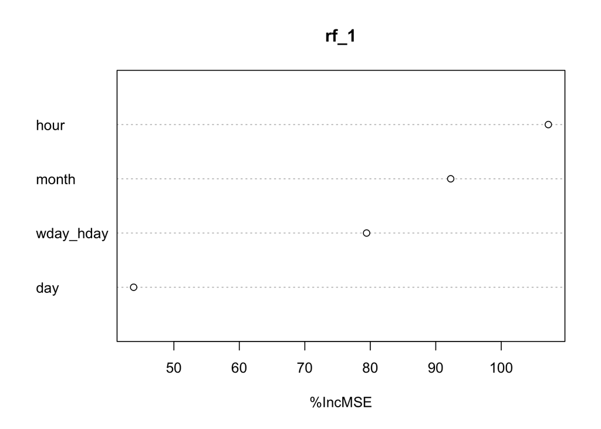

```r
train_x_1 <- df[,c("month", "day", "wday_hday", "hour")] # only dates
train_x_2 <- df[,c('month', 'day', 'wday_hday', 'hour', 'spd', 'vsb', 'temp', 'dewp', 'slp', 'pcp01', 'pcp06', 'pcp24', 'sd')] # all variables
train_x_3 <- df[,c('spd', 'vsb', 'temp', 'dewp', 'slp', 'pcp01', 'pcp06', 'pcp24', 'sd')] # only weather
train_y <- df$pickups # number of pickups
rf_1 <- randomForest(train_x_1, train_y, importance=TRUE) # random forest with dates
rf_2 <- randomForest(train_x_2, train_y, importance=TRUE) # random forest with all variables
rf_3 <- randomForest(train_x_3, train_y, importance=TRUE) # random forest for weather variables
varImpPlot(rf_1, type=1)
```

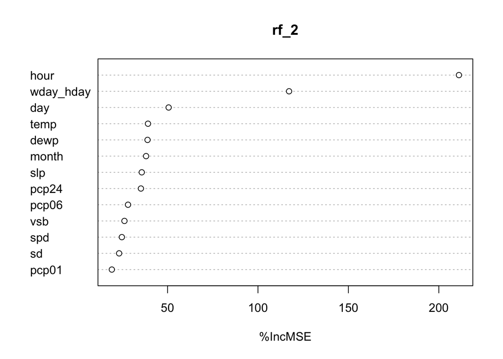

```r
varImpPlot(rf_2, type=1)
```

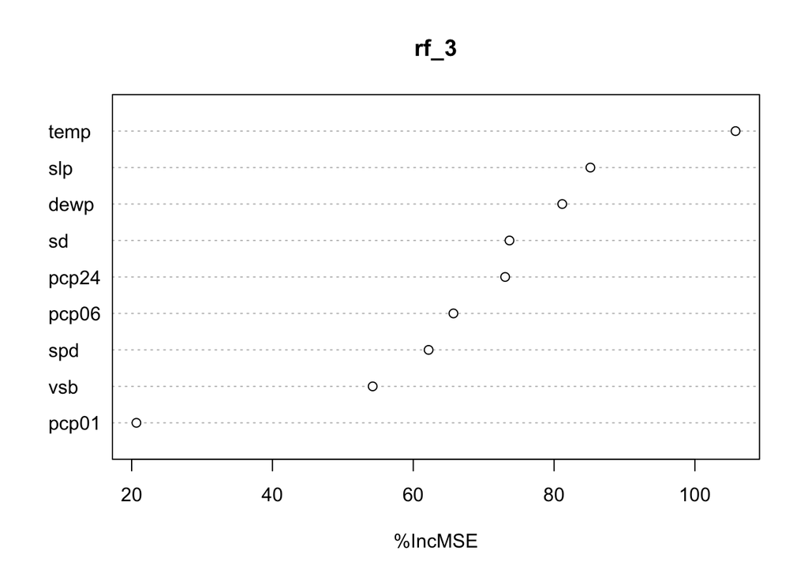

```r
varImpPlot(rf_3, type=1)
```

The x gives the %IncMSE. This is how much the MSE would change if a variable is assigned values by random permutation. We see that the time of day and day of the week are significant.

Out-of-Bag Error is is a measure of the error of prediction for the random forests. Minimizing this value gives a better Random Forest, improving predictive quality.

```
## mtry = 4  OOB error = 287500.4
## Searching left ...
## mtry = 3     OOB error = 378436.9
## -0.3163005 0.05
## Searching right ...
## mtry = 6     OOB error = 218756.9
## 0.2391075 0.05
## mtry = 9     OOB error = 194622.4
## 0.1103258 0.05
## mtry = 13    OOB error = 198216.5
## -0.01846751 0.05
```

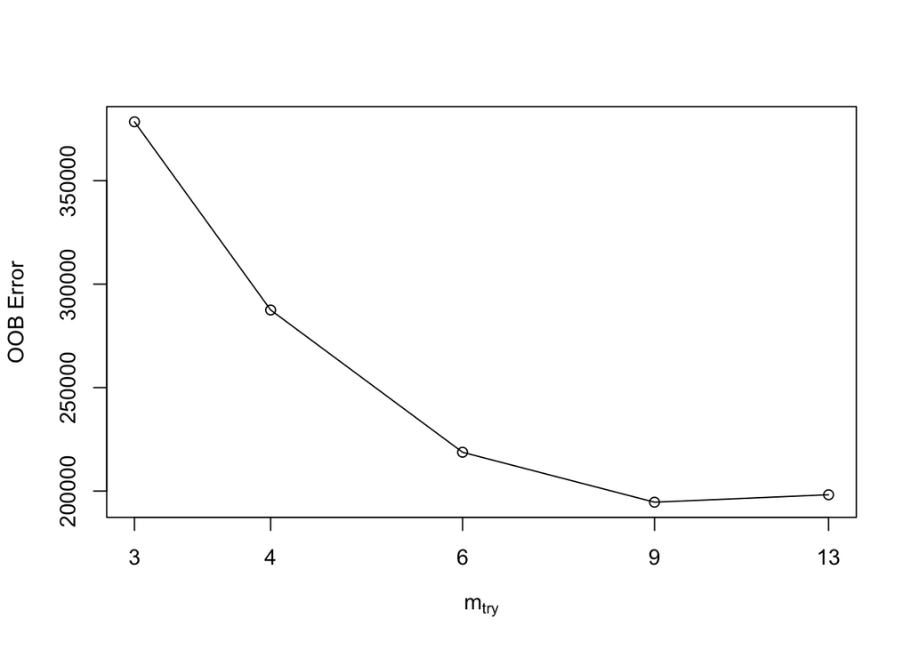

```
##
## Call:
##  randomForest(x = x, y = y, mtry = res[which.min(res[, 2]), 1])
##                Type of random forest: regression
##                      Number of trees: 500
## No. of variables tried at each split: 9
##
##           Mean of squared residuals: 195531.4
##                     % Var explained: 94.1
```

```r
tuneRF(train_x_2, train_y, stepFactor=1.5, improve=0.05, ntree=500, plot=TRUE, doBest=TRUE)
```

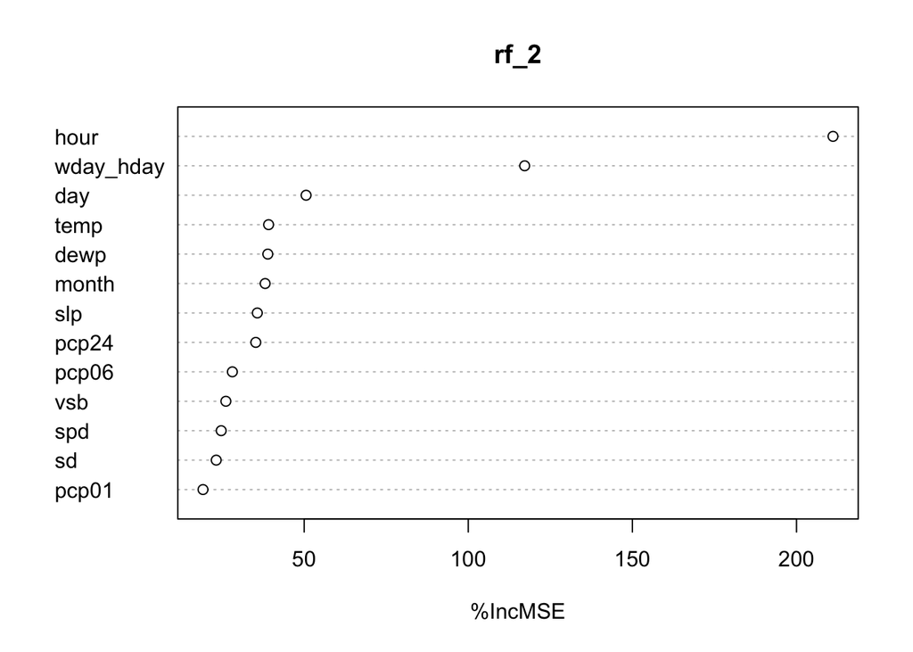

```r
rf_best <- randomForest(train_x_2, train_y, mtry=13, importance=TRUE)
varImpPlot(rf_2, type=1)
```